# session

Cache and restore cookies, [`localStorage`](https://developer.mozilla.org/en-US/docs/Web/API/Window/localStorage), and [`sessionStorage`](https://developer.mozilla.org/en-US/docs/Web/API/Window/sessionStorage) in order to reduce test setup times.

> **Experimental**

> The `session` API is currently experimental, and can be enabled by setting the [`experimentalSessionSupport`](https://docs.cypress.io/guides/references/experiments) flag to `true` in the Cypress config or by using `Cypress.config()` at the top of a spec file.

> Enabling this flag does the following:
> - It adds the `cy.session()` command for use in tests.
> - It adds the `Cypress.session` API.
> - It adds the following new behaviors (that will be the default in a future major update of Cypress) at the beginning of each test:
>   - The page is cleared (by setting it to `about:blank`).
>   - All active session data (cookies, `localStorage` and `sessionStorage`) across all domains are cleared.
> - It overrides the `Cypress.Cookies.preserveOnce()` and `Cypress.Cookies.defaults()` methods.

> Because the page is cleared before each test, `cy.visit()` must be explicitly called in each test to visit a page in your application.

## Syntax

```javascript
cy.session(id, setup)
cy.session(id, setup, options)
```

### Usage

**Correct Usage**

```javascript
// Caching session when logging in via page visit
cy.session(name, () => {
  cy.visit('/login')
  cy.get('[data-test=name]').type(name)
  cy.get('[data-test=password]').type('s3cr3t')
  cy.get('form').contains('Log In').click()
  cy.url().should('contain', '/login-successful')
})

// Caching session when logging in via API
cy.session([username, password], () => {
  cy.request({
    method: 'POST',
    url: '/login',
    body: { username, password },
  }).then(({ body }) => {
    window.localStorage.setItem('authToken', body.token)
  })
})
```

**Incorrect Usage**

```javascript
// visiting before calling cy.session() is redundant, it needs to
// be done inside the setup function
cy.visit('/login')
cy.session(name, () => {
  // need to call cy.visit() here because the page is blank when
  // the setup function runs
  cy.get('[data-test=name]').type(name)
  cy.get('[data-test=password]').type('s3cr3t')
  cy.get('form').contains('Log In').click()
  // should assert that login was successful here to guarantee the
  // login process completes before it is cached
})
// should have asserted this inside the cy.session() setup
// function because the page is blank here
cy.url().should('contain', '/login-successful')
```

### Arguments

**id** *(String, Array, Object)*

A unique identifier that will be used to cache and restore a given session. In simple cases, a `String` value is sufficient. In order to simplify generation of more complex ids, if you pass an `Array` or `Object`, Cypress will generate an id for you by deterministically stringifying the value you pass in. For example, if you pass `['Jane', '123', 'admin']`, an id of `["Jane","123","admin"]` will be generated for you.

> See the choosing the correct id to cache a session section for a more thorough explanation with examples.

> Note that large or cyclical data structures may be slow or difficult to serialize into an identifier, so exercise care with the data you specify.

**setup** *(Function)*

This function is called whenever a session for the given `id` hasn't yet been cached, or if it's no longer valid (see the `validate` option). After `setup` runs, Cypress will preserve all cookies, `sessionStorage`, and `localStorage`, so that subsequent calls to `cy.session()` with the same `id` will bypass `setup` and just restore the cached session data.

The page and all active session data (cookies, `localStorage` and `sessionStorage`) across all domains are always cleared before `setup` runs.

**options** *(Object)*

[output not shown]

### Yields

- `cy.session()` yields `null`.
- `cy.session()` cannot be chained further.

## Examples

### Updating an existing login custom command

You can add session caching to your login custom command. Wrap the inside of the command with a call to `cy.session()`.

**Before**

```javascript
Cypress.Commands.add('login', (username, password) => {
  cy.request({
    method: 'POST',
    url: '/login',
    body: { username, password },
  }).then(({ body }) => {
    window.localStorage.setItem('authToken', body.token)
  })
})
```

**After**

```javascript
Cypress.Commands.add('login', (username, password) => {
  cy.session([username, password], () => {
    cy.request({
      method: 'POST',
      url: '/login',
      body: { username, password },
    }).then(({ body }) => {
      window.localStorage.setItem('authToken', body.token)
    })
  })
})
```

**With session validation**

```javascript
Cypress.Commands.add('login', (username, password) => {
  cy.session(
    [username, password],
    () => {
      cy.request({
        method: 'POST',
        url: '/login',
        body: { username, password },
      }).then(({ body }) => {
        window.localStorage.setItem('authToken', body.token)
      })
    },
    {
      validate() {
        cy.request('/whoami').its('status').should('eq', 200)
      },
    }
  )
})
```

### Updating an existing login helper function

You can add session caching to a login helper function by wrapping the inside of the function with a call to `cy.session()`.

**Before**

```javascript
const login = (name, password) => {
  cy.visit('/login')
  cy.get('[data-test=name]').type(name)
  cy.get('[data-test=password]').type(password)
  cy.get('#submit').click()
  cy.url().should('contain', '/home')
}
```

**After**

```javascript
const login = (name, password) => {
  cy.session([name, password], () => {
    cy.visit('/login')
    cy.get('[data-test=name]').type(name)
    cy.get('[data-test=password]').type(password)
    cy.get('#submit').click()
    cy.url().should('contain', '/home')
  })
}
```

**With session validation**

```javascript
const login = (name, password) => {
  cy.session(
    [name, password],
    () => {
      cy.visit('/login')
      cy.get('[data-test=name]').type(name)
      cy.get('[data-test=password]').type(password)
      cy.get('#submit').click()
      cy.url().should('contain', '/home')
    },
    {
      validate() {
        cy.visit('/account-details')
      },
    }
  )
}
```

### Asserting the session inside setup

Because `cy.session()` caches session data immediately after the `setup` function completes, it's a best practice to assert that the login process has completed at the end of session setup, to ensure that `setup` doesn't return before the session data is available to be cached.

Asserting sessions in this way can help simplify your login custom command, and reduce the need to conditionally cache sessions.

```javascript
cy.session('user', () => {
  cy.visit('/login')
  cy.get('[data-test=name]').type(name)
  cy.get('[data-test=password]').type('p4ssw0rd123')
  cy.get('#login').click()
  // Wait for the post-login redirect to ensure that the
  // session actually exists to be cached
  cy.url().should('contain', '/login-successful')
})
```

### Conditionally caching a session

Specs usually contain two types of tests where logins are necessary:

1. Testing functionality that only exists for logged-in users
2. Testing the act of logging in

For the first, caching sessions can be incredibly useful for reducing the amount of time it takes to run tests. However, for the second, it may be necessary to *not* cache the session, so that other things can be asserted about the login process.

In this case, it can be helpful to create a custom login command that will conditionally cache the session. However, wherever possible, it's better to assert the session inside setup.

```javascript
Cypress.Commands.add('login', (name, { cacheSession = true } = {}) => {
  const login = () => {
    cy.visit('/login')
    cy.get('[data-test=name]').type(name)
    cy.get('[data-test=password]').type('p4ssw0rd123')
    cy.get('#login').click()
  }
  if (cacheSession) {
    cy.session(name, login)
  } else {
    login()
  }
})

// Testing the login flow itself
describe('login', () => {
  it('should redirect to the correct page after logging in', () => {
    cy.login('user', { cacheSession: false })
    cy.url().should('contain', '/login-successful')
  })
})

// Testing something that simply requires being logged in
describe('account details', () => {
  it('should have the correct document title', () => {
    cy.login('user')
    cy.visit('/account')
    cy.title().should('eq', 'User Account Details')
  })
})
```

### Switching sessions inside tests

Because `cy.session()` clears the page and all active session data before running `setup`, you can use it to easily switch between sessions without first needing to log the previous user out. This allows tests to more accurately represent real-world scenarios and helps keep test run times short.

```
const login = (name) => {
  cy.session(name, () => {
    cy.visit('/login')
    cy.get('[data-test=name]').type(name)
    cy.get('[data-test=password]').type('s3cr3t')
    cy.get('#submit').click()
    cy.url().should('contain', '/home')
  })
}

it('should transfer money between users', () => {
  login('user')
  cy.visit('/account')
  cy.get('#amount').type('100.00')
  cy.get('#send-money').click()

  login('other-user')
  cy.visit('/account')
  cy.get('#balance').should('eq', '100.00')
})
```

### Validating the session

If the `validate` function return `false`, throws an exception, returns a Promise that resolves to `false` or rejects, or contains any failing Cypress command, the session will be considered invalid, and `setup` will be re-run.

Here are a few `validate` examples:

```javascript
// Attempt to visit a page that only a logged-in user can see
function validate() {
  cy.visit('/private')
}

// Make an API request that returns a 200 only when logged in
function validate() {
  cy.request('/api/user').its('status').should('eq', 200)
}

// Run any Cypress command that fails if the user is not logged in
function validate() {
  cy.visit('/account', { failOnStatusCode: false })
  cy.url().should('match', /^/account/)
}

// Or just return false if the session is invalid
function validate() {
  if (!MyApp.isSessionValid()) {
    return false
  }
}
```

### Modifying session data before caching

If you want to change which session data is cached, you can modify cookies, `localStorage`, `sessionStorage` as-necessary in `setup`.

```javascript
cy.session('user', () => {
  cy.visit('/login')
  cy.get('name').type('user')
  cy.get('password').type('p4ssw0rd123')
  cy.get('#submit').click()
  cy.url().should('contain', '/home')
  // Remove session data we don't want to cache
  cy.clearCookie('authId')
  cy.window().then((win) => {
    win.localStorage.removeItem('authToken')
  })
  // Add session data we do want to cache
  cy.setCookie('session_id', '189jd09sufh33aaiidhf99d09')
})
```

### Multiple login commands

A more complex app may require multiple login commands, which may require multiple uses of `cy.session()`. However, because the `id` value is used as a unique identifier to save and restore sessions, it's very important that it's actually unique per session.

In the following example, if the resulting session data that `loginByForm` and `loginByApi` create is different *in any way*, it would be a mistake to specify `[name, password]` as the `id` for both, because there would be no way to distinguish between the sessions created by `loginByForm("user", "p4ssw0rd")` and `loginByApi("user", "p4ssw0rd")`. Instead, you can modify the `id` to differentiate its value between both login functions, so that each will always be cached uniquely.

```javascript
const loginByForm = (name, password) => {
  cy.session(['loginByForm', name, password], () => {
    cy.visit('/login')
    cy.get('[data-test=name]').type(name)
    cy.get('[data-test=password]').type(password)
    cy.get('#submit').click()
    cy.url().should('contain', '/home')
  })
}

const loginByApi = (name, password) => {
  cy.session(['loginByApi', name, password], () => {
    cy.request({
      method: 'POST',
      url: '/api/login',
      body: { name, password },
    }).then(({ body }) => {
      window.localStorage.setItem('authToken', body.token)
    })
  })
}
```

### Where to call `cy.visit()`

If you call `cy.visit()` immediately after `cy.setup()` in your login function or custom command, it will effectively behave the same as a login function without any session caching.

```javascript
const login = (name) => {
  cy.session(name, () => {
    cy.visit('/login')
    cy.get('[data-test=name]').type(name)
    cy.get('[data-test=password]').type('s3cr3t')
    cy.get('#submit').click()
    cy.url().should('contain', '/home')
  })
  cy.visit('/home')
}

beforeEach(() => {
  login('user')
})

it('should test something on the /home page', () => {
  // assertions
})

it('should test something else on the /home page', () => {
  // assertions
})
```

But the moment you want to test something on another page, your test will be effectively calling `cy.visit()` twice in a row, which will result in slightly slower tests.

```javascript
// ...continued...

it('should test something on the /other page', () => {
  cy.visit('/other')
  // assertions
})
```

Tests will often be faster if you call `cy.visit()` only when necessary. This works especially well when [organizing tests into suites](https://docs.cypress.io/guides/core-concepts/writing-and-organizing-tests#Test-Structure) and calling `cy.visit()` after logging in inside a [`beforeEach`](https://docs.cypress.io/guides/core-concepts/writing-and-organizing-tests#Hooks) hook.

```javascript
const login = (name) => {
  cy.session(name, () => {
    cy.visit('/login')
    cy.get('[data-test=name]').type(name)
    cy.get('[data-test=password]').type('s3cr3t')
    cy.get('#submit').click()
    cy.url().should('contain', '/home')
  })
  // no visit here
}

describe('home page tests', () => {
  beforeEach(() => {
    login('user')
    cy.visit('/home')
  })

  it('should test something on the /home page', () => {
    // assertions
  })

  it('should test something else on the /home page', () => {
    // assertions
  })
})

describe('other page tests', () => {
  beforeEach(() => {
    login('user')
    cy.visit('/other')
  })

  it('should test something on the /other page', () => {
    // assertions
  })
})
```

### Updating a login function that returns a value

If your custom login command returns a value that you use to assert in a test, wrapping it with `cy.session()` will break that test. However, it's usually easy to solve this by refactoring the login code to assert directly inside `setup`.

**Before**

```javascript
Cypress.Commands.add('loginByApi', (username, password) => {
  return cy.request('POST', `/api/login`, {
    username,
    password,
  })
})

it('should return the correct value', () => {
  cy.loginByApi('user', 's3cr3t').then((response) => {
    expect(response.status).to.eq(200)
  })
})
```

**After**

```javascript
Cypress.Commands.add('loginByApi', (username, password) => {
  cy.session([username, password], () => {
    cy.request('POST', `/api/login`, {
      username,
      password,
    }).then((response) => {
      expect(response.status).to.eq(200)
    })
  })
})

it('is a redundant test', () => {
  /* which you can now delete! */
})
```

### Cross-domain sessions

It's possible to switch domains while caching sessions, just be sure to explicitly visit the domain in your login command before calling `cy.session()`.

```
const login = (name) => {
  if (location.hostname !== 'example.com') {
    cy.visit('example.com')
  }
  cy.session(name, () => {
    cy.visit('/login')
    // etc
  }, {
    validate() {
      cy.request('/whoami', {
        headers: { 'Authorization' : localStorage.token }
        method: 'POST'
      }).its('status').should('equal', 200)
    }
  })
}

it('t1', ()=>{
  login('bob')
  // do things on example.com
})

it('t2', ()=>{
  cy.visit('anotherexample.com')
  // do things on anotherexample.com
})

it('t3', ()=>{
  login('bob')
  // do things on example.com
})
```

## Notes

### When the page and active session data are cleared

The page is cleared and all active session data (cookies, `localStorage`, and `sessionStorage`) across all domains are cleared automatically when `cy.session()` runs. This guarantees consistent behavior whether a session is being created or restored and allows you to switch sessions without first having to explicitly log out.

[output not shown]

Because calling `cy.session()` clears the current page in addition to restoring cached session data, `cy.visit()` must always be explicitly called afterwards to ensure a page is visited.

### Session caching

Once created, a session for a given `id` is cached for the duration of the spec file. You can't modify a stored session after it has been cached, but you can always create a new session with a different `id`.

In order to reduce development time, when running the Test Runner in "open" mode, sessions will be cached *between spec file runs* as long as the `setup` function hasn't changed.

### Explicitly clearing sessions

When running the Test Runner in "open" mode, you can explicitly clear all sessions and re-run the spec file by clicking the "Clear All Sessions" button in the Instrument Panel.

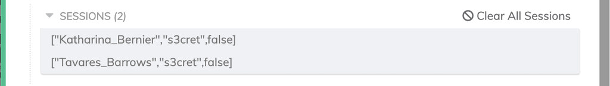

For debugging purposes, all sessions can be cleared with the `Cypress.session.clearAllSavedSessions()` method.

### Where to call `cy.session()`

While it is possible to call `cy.session()` explicitly inside a test or `beforeEach`, it is considered a best practice to call `cy.session()` inside a login custom command or reusable wrapper function. See the Updating an existing login custom command and Updating an existing login helper function examples for more details.

### Choosing the correct id to cache a session

In order for sessions to be cached uniquely, the `id` argument must be unique for each new session created.

```javascript
// If your session setup code uses a string variable, pass in the
// string as the id
const login = (name) => {
  cy.session(name, () => {
    loginWith(name)
  })
}

// If your session setup code uses a single object, pass in the
// object as the id and it will be serialized into an identifier
const login = (params = {}) => {
  cy.session(params, () => {
    loginWith(params)
  })
}

// If your session setup code uses multiple variables, pass in an
// array of those variables and it will be serialized into an
// identifier
const login = (name, email, params = {}) => {
  cy.session([name, email, params], () => {
    loginWith(name, email, params)
  })
}

// If your session setup code uses external constants, they don't
// need to be included in the id, since they will never change
const API_KEY = 'I_AM_AN_API_KEY'
const login = (name, email) => {
  cy.session([name, email], () => {
    loginWith(name, email, API_KEY)
  })
}
```

**Incorrect Usage**

If you have custom `login` code that uses multiple parameters (in this example, a name, a token, and a password), in order to be able to log in many different users, but the `id` only included one of them (in this example, `name`):

```javascript
const login = (name, token, password) => {
  cy.session(name, () => {
    cy.visit('/login')
    cy.get('[data-test=name]').type(name)
    cy.get('[data-test=token]').type(token)
    cy.get('[data-test=password]').type(password)
    cy.get('#submit').click()
  })
}
```

If you ran this, `user1` would be logged in with `token1` and `p4ssw0rd`, and a session would be created and cached using `"user1"` as the `id`.

```javascript
login('user1', 'token1', 'p4ssw0rd')
```

Now let's say you wanted to try to log in the same user, but with a different token and/or password, and expect a different session to be created and cached. You run this, but because `cy.session()` is only being passed `name` as its `id`, it won't create a new session, but will instead load the saved session for `"user1"`.

```javascript
login('user1', 'different-token', 'p4ssw0rd')
```

In summary, you need to ensure that the `id` is created from all the parameters that are used inside the `setup` function that may change, otherwise `id` values may collide and create unexpected results.

**Correct Usage**

In this example, setting the `id` to `[name, token, password]` guarantees that calling `login()` with different `name`, `token` and `password` values will create and cache unique sessions.

```javascript
const login = (name, token, password) => {
  cy.session([name, token, password], () => {
    cy.visit('/login')
    cy.get('[data-test=name]').type(name)
    cy.get('[data-test=token]').type(token)
    cy.get('[data-test=password]').type(password)
    cy.get('#submit').click()
  })
}
```

### Common Questions

#### Why are all my Cypress commands failing after calling `cy.session()`?

Ensure that you're calling `cy.visit()` after calling `cy.session()`, otherwise your tests will be running on a blank page.

#### Why am I seeing `401` errors after calling `cy.session()`?

It's possible that your session has been invalidated. Be sure to specify a `validate` function so that `cy.session()` can validate and recreate the session if necessary.

## Command Log

### The Instrument Panel

Whenever a session is created or restored inside a test, an extra instrument panel is displayed at the top of the test to give more information about the state of your sessions.

Clicking any session `id` in the panel will print that session's details to the console, and clicking the "Clear All Sessions" button will clear all saved sessions and re-run the spec file (see Session caching for more details).

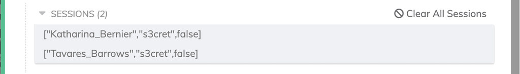

### The command log

Whenever `cy.session()` is called, the command log will show one of the following lines, which includes the status of the session call along with the session `id` value:

- No saved session was found, so a new session was created and saved:

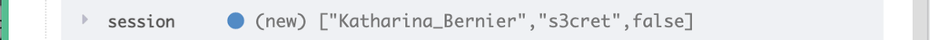

- A saved session was found, and used:

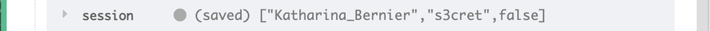

- A saved session was found, but the `validate` function failed, so the session was recreated and saved:

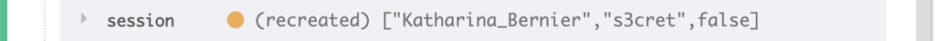

Note that in cases where the `validate` function fails immediately after `setup` creates the session, the test will fail with an error.

Expanding the session group in the command log will show all of the commands that were run when creating and/or validating the session.

In this image, a saved session is restored, but when `/personal` is visited in the `validate` function, the app redirects to `/signin`, which invalidates the session. A new session is created by visiting `/signin` where the user is logged in, after which, validation succeeds, and the session is made active for the remainder of the test.

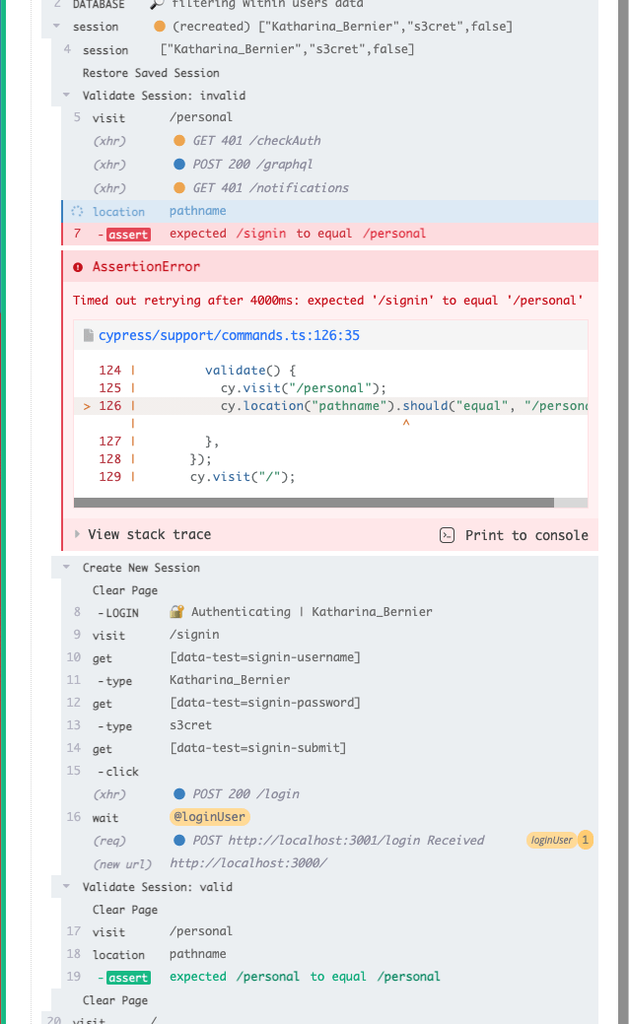

### Printing to the console

Clicking a session `id` in the Instrument Panel or clicking the first line under an expanded session group in the command log will print that session's details to the console. This information contains the `id` along with any cached session data, including cookies, `localStorage` and `sessionStorage`.

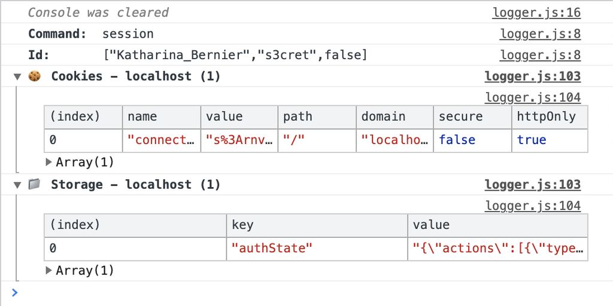

## See also

- [Authenticate faster in tests with the cy.session command](https://cypress.io/blog/2021/08/04/authenticate-faster-in-tests-cy-session-command/)
- Custom Commands
- `Cypress.session`
- `cy.visit()`

© 2017 Cypress.io  
Licensed under the MIT License.  
https://docs.cypress.io/api/commands/session